# Clase 3

## Ajuste de la mejor recta de regresión

- Sea $Y_i$ la estatura del hijo $i^{th}$ y $X_i$ la estatura del padre $i^{th}$.
- Considere la recta con mejor ajuste $Y_i = \beta_0 + \beta_1 X_i + \varepsilon_i$.
- La ecuación de mínimos cuadrados es
  $$\sum_{i=1}^n [Y_i - (\beta_0 + \beta_1 X_i)]^2.$$

## Resultados

- El modelo de mínimos cuadrados ajusta la recta $Y = \beta_0 + \beta_1 X$ a través de los pares ordenados $(X_i, Y_i)$ e $Y_i$ es el output que se obtiene de la recta $Y = \hat \beta_0 + \hat \beta_1 X$ con
  $$\hat \beta_1 = Cor(Y, X) \frac{Sd(Y)}{Sd(X)} ~~~ \hat \beta_0 = \bar Y - \hat \beta_1 \bar X.$$
- $\hat \beta_1$ se expresa en unidades de $Y / X$, $\hat \beta_0$ se expresa en unidades de $Y$.
- La recta de regresión pasa por $(\bar X, \bar Y)$.
- La pendiente de la recta de regresión con $X$ como output e $Y$ como input es $Cor(Y, X) \frac{Sd(X)}{Sd(Y)}$.
- La pendiente es la misma que se obtiene que si se centraran los datos $(X_i - \bar X, Y_i - \bar Y)$ y se estimara una regresión que pasa por $(0,0)$.
- Si se normalizan los datos $\left(\displaystyle\frac{X_i - \bar X}{Sd(X)}, \displaystyle\frac{Y_i - \bar Y}{Sd(Y)} \right)$, la pendiente es $Cor(Y, X)$.

## En síntesis

Es interesante notar que las estimaciones del programa coinciden con el cálculo siguiendo las fórmulas por definición.

```r
y <- galton$child
x <- galton$parent
beta1 <- cor(y, x) *  sd(y) / sd(x)
beta0 <- mean(y) - beta1 * mean(x)
rbind(c(beta0, beta1), coef(lm(y ~ x)))
```

```
##      (Intercept)         x
## [1,]    23.94153 0.6462906
## [2,]    23.94153 0.6462906
```

La regresión desde el origen conserva la pendiente si primero centramos los datos

```r
yc <- y - mean(y)
xc <- x - mean(x)
beta1 <- sum(yc * xc) / sum(xc ^ 2)
c(beta1, coef(lm(y ~ x))[2])
```

```
##                   x
## 0.6462906 0.6462906
```

Si se normalizan los datos la pendiente es igual al coeficiente de correlación

```r
yn <- (y - mean(y))/sd(y)
xn <- (x - mean(x))/sd(x)
c(cor(y, x), cor(yn, xn), coef(lm(yn ~ xn))[2])
```

```
##                            xn
## 0.4587624 0.4587624 0.4587624
```

Mejor recta de regresión:

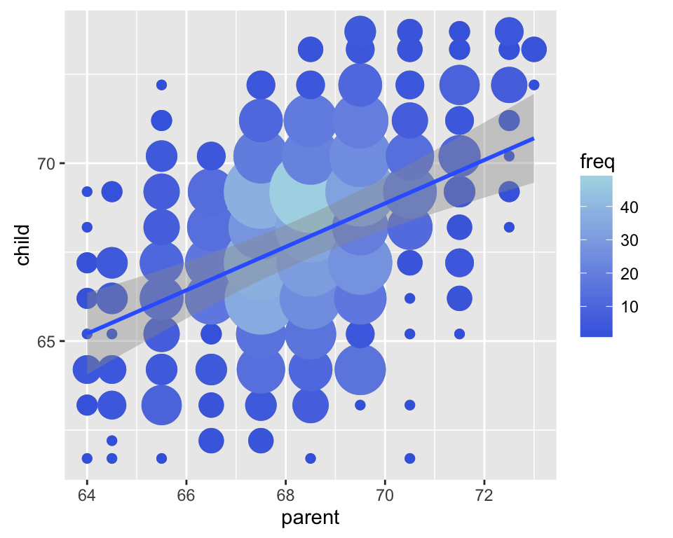

# Modelo Lineal Multivariado

## Extensión del caso univariado

- El modelo lineal generalizado extiende el modelo lineal simple (SLR) agregando términos linealmente al modelo. Típicamente $X_{1i}=1$ (se incluye un intercepto).
  $$Y_i = \beta_1 X_{1i} + \beta_2 X_{2i} + \ldots +
  \beta_{p} X_{pi} + \epsilon_{i}
  = \sum_{k=1}^p X_{ik} \beta_j + \varepsilon_{i}.$$
- La estimación por OLS (y también la estimación por ML bajo supuestos de iid y errores Gaussianos) minimiza
  $$\sum_{i=1}^n \left(Y_i - \sum_{k=1}^p X_{ki} \beta_j\right)^2.$$
- Lo importante es la linealidad de los coeficientes, entonces
  $$Y_i = \beta_1 X_{1i}^2 + \beta_2 X_{2i}^2 + \ldots +
  \beta_{p} X_{pi}^2 + \varepsilon_{i}.$$
  también es un modelo lineal (aunque los regresores sean términos cuadráticos).

## Interpretación de los coeficientes

$$E[Y | X_1 = x_1, \ldots, X_p = x_p] = \sum_{k=1}^p x_{k} \beta_k$$

$$E[Y | X_1 = x_1 + 1, \ldots, X_p = x_p] = (x_1 + 1) \beta_1 + \sum_{k=2}^p x_{k} \beta_k$$

$$E[Y | X_1 = x_1 + 1, \ldots, X_p = x_p] - E[Y | X_1 = x_1, \ldots, X_p = x_p] = (x_1 + 1) \beta_1 + \sum_{k=2}^p x_{k} \beta_k - \sum_{k=1}^p x_{k} \beta_k = \beta_1$$
Un coeficiente de regresión multivariada es el cambio esperado en el output ante un cambio en una unidad en el regresor correspondiente, manteniendo todos los demás regresores fijos.

# Tasas de hambre en la población infantil

Instancia de trabajo

```r
#link descarga
url <- "http://apps.who.int/gho/athena/data/GHO/WHOSIS_000008.csv"
file <- "hunger.csv"

if(!file.exists(file)) {
  print("descargando")
  download.file(url, file, method="curl")
}

hunger <- read.csv("hunger.csv")
hunger <- hunger[hunger$Sex!="Both sexes",]
```

## Modelo univariado

### Sin controlar por género

$$H_i = b_0 + b_1 Y_i + e_i$$

$b_0$ = % de hambre en el año 0

$b_1$ = disminución del % de hambre por año

$e_i$ = todas las variables no medidas

```r
lm1 <- lm(hunger$Numeric ~ hunger$Year)
summary(lm1)
```

```
##
## Call:
## lm(formula = hunger$Numeric ~ hunger$Year)
##
## Residuals:
##     Min      1Q  Median      3Q     Max
## -24.489 -11.174  -1.965   7.314  45.111
##
## Coefficients:
##              Estimate Std. Error t value Pr(>|t|)
## (Intercept) 628.20668  108.38208   5.796 8.93e-09 ***
## hunger$Year  -0.30528    0.05412  -5.640 2.17e-08 ***
## ---
## Signif. codes:  0 '***' 0.001 '**' 0.01 '*' 0.05 '.' 0.1 ' ' 1
##
## Residual standard error: 13.07 on 1062 degrees of freedom
## Multiple R-squared:  0.02909,    Adjusted R-squared:  0.02817
## F-statistic: 31.82 on 1 and 1062 DF,  p-value: 2.173e-08
```

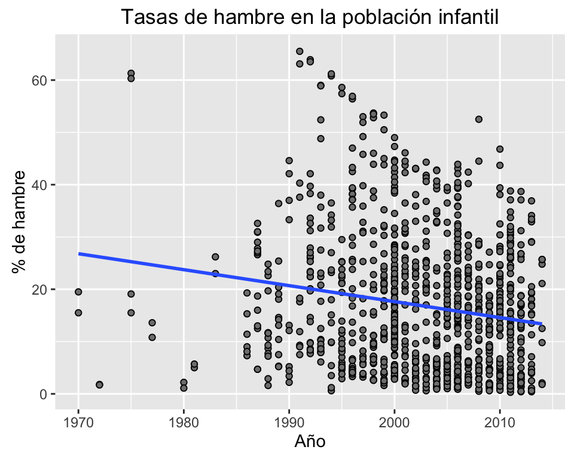

```r
ggplot(hunger, aes(x=Year, y=Numeric)) + geom_point(shape=21,fill="grey50") + geom_smooth(method=lm, se=FALSE) +
  ggtitle("Tasas de hambre en la población infantil") +
  scale_x_continuous(name = "Año") +
  scale_y_continuous(name = "% de hambre")
```

### Controlando por género

$$HF_i = bf_0 + bf_1 YF_i + ef_i$$

$bf_0$ = % de hambre en las niñas en el año 0

$bf_1$ = disminución del % de hambre por año en las niñas

$ef_i$ = todas las variables no medidas

$$HM_i = bm_0 + bm_1 YM_i + em_i$$

$bm_0$ = % de hambre en los niños en el año 0

$bm_1$ = disminución del % de hambre por año en las niños

$em_i$ = todas las variables no medidas

```r
lmM <- lm(hunger$Numeric[hunger$Sex=="Male"] ~ hunger$Year[hunger$Sex=="Male"])
lmF <- lm(hunger$Numeric[hunger$Sex=="Female"] ~ hunger$Year[hunger$Sex=="Female"])

summary(lmM)
```

```
##
## Call:
## lm(formula = hunger$Numeric[hunger$Sex == "Male"] ~ hunger$Year[hunger$Sex ==
##     "Male"])
##
## Residuals:
##     Min      1Q  Median      3Q     Max
## -25.801 -11.630  -1.609   7.659  42.319
##
## Coefficients:
##                                    Estimate Std. Error t value Pr(>|t|)
## (Intercept)                       660.57793  156.24779   4.228 2.78e-05
## hunger$Year[hunger$Sex == "Male"]  -0.32098    0.07803  -4.114 4.51e-05
##
## (Intercept)                       ***
## hunger$Year[hunger$Sex == "Male"] ***
## ---
## Signif. codes:  0 '***' 0.001 '**' 0.01 '*' 0.05 '.' 0.1 ' ' 1
##
## Residual standard error: 13.32 on 530 degrees of freedom
## Multiple R-squared:  0.03094,    Adjusted R-squared:  0.02911
## F-statistic: 16.92 on 1 and 530 DF,  p-value: 4.512e-05
```

```r
summary(lmF)
```

```
##
## Call:
## lm(formula = hunger$Numeric[hunger$Sex == "Female"] ~ hunger$Year[hunger$Sex ==
##     "Female"])
##
## Residuals:
##     Min      1Q  Median      3Q     Max
## -23.077 -10.516  -1.997   6.925  46.225
##
## Coefficients:
##                                      Estimate Std. Error t value Pr(>|t|)
## (Intercept)                         595.83544  149.72526   3.980 7.87e-05
## hunger$Year[hunger$Sex == "Female"]  -0.28958    0.07477  -3.873 0.000121
##
## (Intercept)                         ***
## hunger$Year[hunger$Sex == "Female"] ***
## ---
## Signif. codes:  0 '***' 0.001 '**' 0.01 '*' 0.05 '.' 0.1 ' ' 1
##
## Residual standard error: 12.77 on 530 degrees of freedom
## Multiple R-squared:  0.02752,    Adjusted R-squared:  0.02569
## F-statistic:    15 on 1 and 530 DF,  p-value: 0.0001209
```

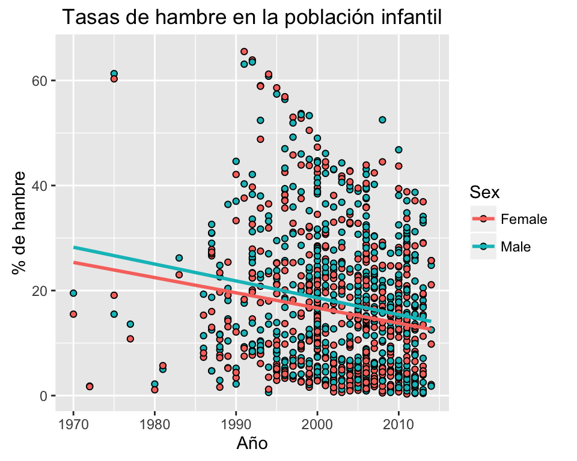

```r
ggplot(hunger, aes(x=Year, y=Numeric, fill=Sex)) + geom_point(shape=21) + geom_smooth(method=lm, aes(color=Sex), se=FALSE) +
  ggtitle("Tasas de hambre en la población infantil") +
  scale_x_continuous(name = "Año") +
  scale_y_continuous(name = "% de hambre")
```

## Modelo multivariado

### Especificación 1

$$H_i = b_0 + b_1 M_i + b_2 Y_i + e^*_i$$

$b_0$ = % de hambre en las niñas en el año 0

$M_i$ = $\begin{cases} 1 &\text{si es niño} \cr 0 &\text{si es niña} \end{cases}$

$b_0 + b_1$ = % de hambre en las niños en el año 0

$b_2$ = disminución del % de hambre por año en niños o niñas

$e^*_i$ = todas las variables no medidas

```r
lmBoth <- lm(hunger$Numeric ~ hunger$Year + hunger$Sex)
summary(lmBoth)
```

```
##
## Call:
## lm(formula = hunger$Numeric ~ hunger$Year + hunger$Sex)
##
## Residuals:
##     Min      1Q  Median      3Q     Max
## -25.323 -11.211  -1.751   7.135  46.045
##
## Coefficients:
##                 Estimate Std. Error t value Pr(>|t|)
## (Intercept)    627.27313  108.15643   5.800 8.76e-09 ***
## hunger$Year     -0.30528    0.05401  -5.652 2.03e-08 ***
## hunger$SexMale   1.86711    0.79975   2.335   0.0197 *
## ---
## Signif. codes:  0 '***' 0.001 '**' 0.01 '*' 0.05 '.' 0.1 ' ' 1
##
## Residual standard error: 13.04 on 1061 degrees of freedom
## Multiple R-squared:  0.03405,    Adjusted R-squared:  0.03223
## F-statistic:  18.7 on 2 and 1061 DF,  p-value: 1.044e-08
```

### Especificación 2

$$H_i = b_0 + b_1 M_i + b_2 Y_i + b_3 (M_i \cdot Y_i) + e^+_i$$

$b_0$ = % de hambre en las niñas en el año 0

$M_i$ = $\begin{cases} 1 &\text{si es niño} \cr 0 &\text{si es niña} \end{cases}$

$b_0 + b_1$ = % de hambre en las niños en el año 0

$b_2 + b_3$ = disminución del % de hambre por año en los niños

$e^+_i$ = todas las variables no medidas

```r
lmBoth2 <- lm(hunger$Numeric ~ hunger$Year + hunger$Sex + hunger$Sex*hunger$Year)
summary(lmBoth2)
```

```
##
## Call:
## lm(formula = hunger$Numeric ~ hunger$Year + hunger$Sex + hunger$Sex *
##     hunger$Year)
##
## Residuals:
##     Min      1Q  Median      3Q     Max
## -25.801 -11.147  -1.753   7.213  46.225
##
## Coefficients:
##                             Estimate Std. Error t value Pr(>|t|)
## (Intercept)                595.83544  153.02128   3.894 0.000105 ***
## hunger$Year                 -0.28958    0.07642  -3.790 0.000159 ***
## hunger$SexMale              64.74249  216.40478   0.299 0.764867
## hunger$Year:hunger$SexMale  -0.03140    0.10807  -0.291 0.771454
## ---
## Signif. codes:  0 '***' 0.001 '**' 0.01 '*' 0.05 '.' 0.1 ' ' 1
##
## Residual standard error: 13.05 on 1060 degrees of freedom
## Multiple R-squared:  0.03413,    Adjusted R-squared:  0.03139
## F-statistic: 12.48 on 3 and 1060 DF,  p-value: 5.018e-08
```

### Residuos

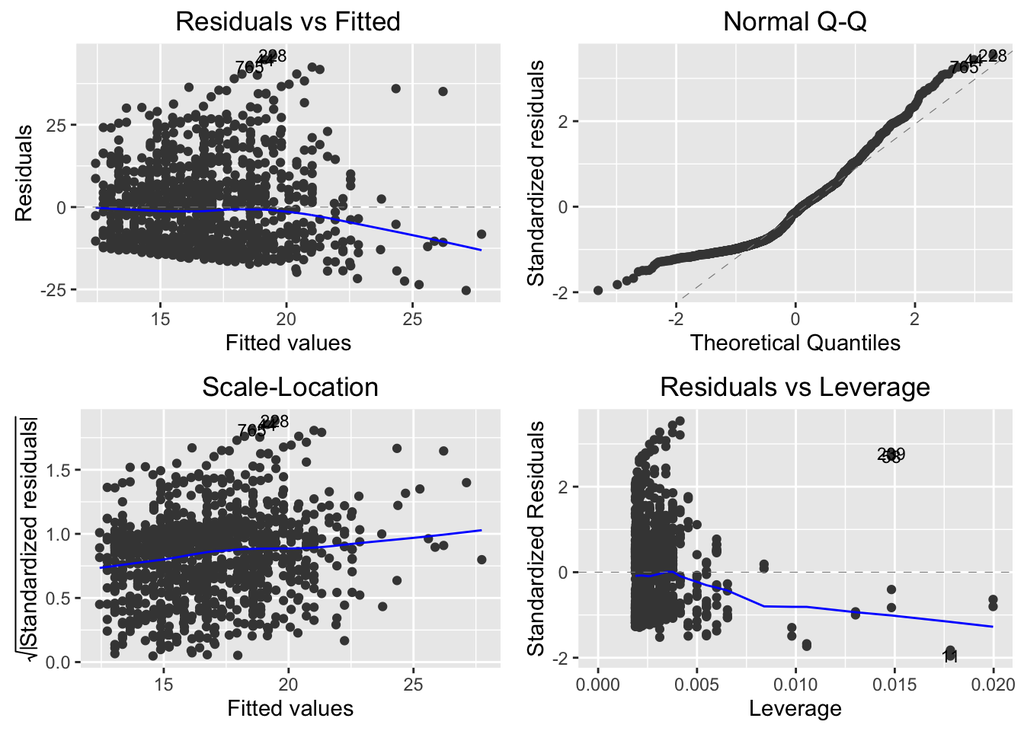

```r
autoplot(lmBoth, label.size = 3)
```

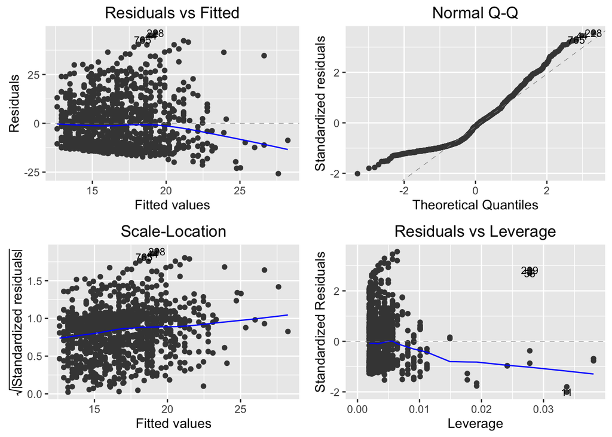

```r
autoplot(lmBoth2, label.size = 3)
```

# Ejemplo: Economic Fluctuations in the United States 1921–1941 (Klein)

- El paper de Klein es un paper clásico de la economía keynesiana.
- Propone un mecanismo de funcionamiento de la economía bastante simple
- Ideal para estudiar regresiones en una primera etapa
- Los datos originales están disponibles en la extensión `sem`

Las variables de la base de datos original son:

- Year: 1921–1941
- C = private consumption expenditure.
- P = profits net of business taxes.
- WP = wage bill of the private sector.
- WG = wage bill of the government sector.
- I = (net) private investment.
- K = stock of (private) capital goods (at the end of the year).
- A = an index of the passage of time, 1931 = zero.
- G = government expenditure plus net exports.
- T = business taxes.
- X = gross national product.

Las ecuaciones que Klein testea son:
$$Ct = \alpha_1 + \alpha_2 P_t + \alpha_3 P_{t-1} + \alpha_4 (WP_t + WG_t)$$
$$I_t = \beta_1 + \beta_2 P_t + \beta_3 P_{t-1} - \beta_4 K_{t-1}$$
$$WPt = \gamma_1 + \gamma_2 X_t + \gamma_3 X_{t-1} + \gamma_4 A$$
$$Pt = X_t - WP_t - T_t$$
$$K_t = K_{t-1} + I_t$$
$$X_t = C_t + I_t + G_t$$

Veamos las variables de la base de datos:

```r
str(Klein)
```

```
## 'data.frame':    22 obs. of  10 variables:
##  $ Year : int  1920 1921 1922 1923 1924 1925 1926 1927 1928 1929 ...
##  $ C    : num  39.8 41.9 45 49.2 50.6 52.6 55.1 56.2 57.3 57.8 ...
##  $ P    : num  12.7 12.4 16.9 18.4 19.4 20.1 19.6 19.8 21.1 21.7 ...
##  $ Wp   : num  28.8 25.5 29.3 34.1 33.9 35.4 37.4 37.9 39.2 41.3 ...
##  $ I    : num  2.7 -0.2 1.9 5.2 3 5.1 5.6 4.2 3 5.1 ...
##  $ K.lag: num  180 183 183 184 190 ...
##  $ X    : num  44.9 45.6 50.1 57.2 57.1 61 64 64.4 64.5 67 ...
##  $ Wg   : num  2.2 2.7 2.9 2.9 3.1 3.2 3.3 3.6 3.7 4 ...
##  $ G    : num  2.4 3.9 3.2 2.8 3.5 3.3 3.3 4 4.2 4.1 ...
##  $ T    : num  3.4 7.7 3.9 4.7 3.8 5.5 7 6.7 4.2 4 ...
```

En el caso de la ecuación $Ct = \alpha_1 + \alpha_2 P_t + \alpha_3 P_{t-1} + \alpha_4 (WP_t + WG_t)$ lo primero es construir las variables `P.lag` y `X.lag` que no están en los datos.

Luego $Ct = \alpha_1 + \alpha_2 P_t + \alpha_3 P_{t-1} + \alpha_4 (WP_t + WG_t)$ en R es

```
C ~ P + P.lag + I(Wp + Wg)
```

Para estimar los coeficientes de esta ecuación se hará lo ya visto anteriormente

```r
Klein$P.lag <- c(NA, Klein$P[-22])
Klein$X.lag <- c(NA, Klein$X[-22])

summary(lm(C ~ P + P.lag + I(Wp + Wg), data=Klein))
```

```
##
## Call:
## lm(formula = C ~ P + P.lag + I(Wp + Wg), data = Klein)
##
## Residuals:
##      Min       1Q   Median       3Q      Max
## -2.17345 -0.43597 -0.03466  0.78508  1.61650
##
## Coefficients:
##             Estimate Std. Error t value Pr(>|t|)
## (Intercept) 16.23660    1.30270  12.464 5.62e-10 ***
## P            0.19293    0.09121   2.115   0.0495 *
## P.lag        0.08988    0.09065   0.992   0.3353
## I(Wp + Wg)   0.79622    0.03994  19.933 3.16e-13 ***
## ---
## Signif. codes:  0 '***' 0.001 '**' 0.01 '*' 0.05 '.' 0.1 ' ' 1
##
## Residual standard error: 1.026 on 17 degrees of freedom
##   (1 observation deleted due to missingness)
## Multiple R-squared:  0.981,  Adjusted R-squared:  0.9777
## F-statistic: 292.7 on 3 and 17 DF,  p-value: 7.938e-15
```

Para estimar los coeficientes de $I$ y $Wp$ se procede del mismo modo

```r
summary(lm(I ~ P + P.lag + K.lag, data=Klein))
```

```
##
## Call:
## lm(formula = I ~ P + P.lag + K.lag, data = Klein)
##
## Residuals:
##      Min       1Q   Median       3Q      Max
## -2.56562 -0.63169  0.03687  0.41542  1.49226
##
## Coefficients:
##             Estimate Std. Error t value Pr(>|t|)
## (Intercept) 10.12579    5.46555   1.853 0.081374 .
## P            0.47964    0.09711   4.939 0.000125 ***
## P.lag        0.33304    0.10086   3.302 0.004212 **
## K.lag       -0.11179    0.02673  -4.183 0.000624 ***
## ---
## Signif. codes:  0 '***' 0.001 '**' 0.01 '*' 0.05 '.' 0.1 ' ' 1
##
## Residual standard error: 1.009 on 17 degrees of freedom
##   (1 observation deleted due to missingness)
## Multiple R-squared:  0.9313, Adjusted R-squared:  0.9192
## F-statistic: 76.88 on 3 and 17 DF,  p-value: 4.299e-10
```

```r
summary(lm(Wp ~ X + X.lag + I(Year - 1931), data=Klein))
```

```
##
## Call:
## lm(formula = Wp ~ X + X.lag + I(Year - 1931), data = Klein)
##
## Residuals:
##      Min       1Q   Median       3Q      Max
## -1.29418 -0.46875  0.01376  0.45027  1.19569
##
## Coefficients:
##                Estimate Std. Error t value Pr(>|t|)
## (Intercept)     1.49704    1.27003   1.179 0.254736
## X               0.43948    0.03241  13.561 1.52e-10 ***
## X.lag           0.14609    0.03742   3.904 0.001142 **
## I(Year - 1931)  0.13025    0.03191   4.082 0.000777 ***
## ---
## Signif. codes:  0 '***' 0.001 '**' 0.01 '*' 0.05 '.' 0.1 ' ' 1
##
## Residual standard error: 0.7671 on 17 degrees of freedom
##   (1 observation deleted due to missingness)
## Multiple R-squared:  0.9874, Adjusted R-squared:  0.9852
## F-statistic: 444.6 on 3 and 17 DF,  p-value: 2.411e-16
```

El paper original utiliza una metodología denominada Mínimos Cuadrados en dos Etapas y luego Structural Equation Modelling ¿por qué?

Estas son las regresiones con la metodología del paper original:

```r
#install.packages("sem")
library(sem)

Klein$P.lag <- c(NA, Klein$P[-22])
Klein$X.lag <- c(NA, Klein$X[-22])

summary(tsls(C ~ P + P.lag + I(Wp + Wg),
    instruments=~1 + G + T + Wg + I(Year - 1931) + K.lag + P.lag + X.lag,
    data=Klein))
```

```
##
##  2SLS Estimates
##
## Model Formula: C ~ P + P.lag + I(Wp + Wg)
##
## Instruments: ~1 + G + T + Wg + I(Year - 1931) + K.lag + P.lag + X.lag
##
## Residuals:
##    Min. 1st Qu.  Median    Mean 3rd Qu.    Max.
## -1.8930 -0.6163 -0.2459  0.0000  0.8854  2.0030
##
##                Estimate  Std. Error  t value   Pr(>|t|)
## (Intercept) 16.55475577  1.46797870 11.27725 2.5869e-09 ***
## P            0.01730221  0.13120458  0.13187   0.896634
## P.lag        0.21623404  0.11922168  1.81371   0.087413 .
## I(Wp + Wg)   0.81018270  0.04473506 18.11069 1.5050e-12 ***
## ---
## Signif. codes:  0 '***' 0.001 '**' 0.01 '*' 0.05 '.' 0.1 ' ' 1
##
## Residual standard error: 1.1356586 on 17 degrees of freedom
```

```r
summary(tsls(I ~ P + P.lag + K.lag,
    instruments=~1 + G + T + Wg + I(Year - 1931) + K.lag + P.lag + X.lag,
    data=Klein))
```

```
##
##  2SLS Estimates
##
## Model Formula: I ~ P + P.lag + K.lag
##
## Instruments: ~1 + G + T + Wg + I(Year - 1931) + K.lag + P.lag + X.lag
##
## Residuals:
##    Min. 1st Qu.  Median    Mean 3rd Qu.    Max.
## -3.2910 -0.8069  0.1423  0.0000  0.8601  1.7960
##
##                Estimate  Std. Error  t value  Pr(>|t|)
## (Intercept) 20.27820896  8.38324891  2.41890 0.0270705 *
## P            0.15022182  0.19253359  0.78024 0.4459798
## P.lag        0.61594358  0.18092585  3.40440 0.0033755 **
## K.lag       -0.15778764  0.04015207 -3.92975 0.0010797 **
## ---
## Signif. codes:  0 '***' 0.001 '**' 0.01 '*' 0.05 '.' 0.1 ' ' 1
##
## Residual standard error: 1.3071491 on 17 degrees of freedom
```

```r
summary(tsls(Wp ~ X + X.lag + I(Year - 1931),
    instruments=~1 + G + T + Wg + I(Year - 1931) + K.lag + P.lag + X.lag,
    data=Klein))
```

```
##
##  2SLS Estimates
##
## Model Formula: Wp ~ X + X.lag + I(Year - 1931)
##
## Instruments: ~1 + G + T + Wg + I(Year - 1931) + K.lag + P.lag + X.lag
##
## Residuals:
##    Min. 1st Qu.  Median    Mean 3rd Qu.    Max.
## -1.2940 -0.4734  0.0145  0.0000  0.4487  1.1960
##
##                  Estimate Std. Error  t value   Pr(>|t|)
## (Intercept)    1.50029689 1.27568637  1.17607 0.25577411
## X              0.43885907 0.03960266 11.08155 3.3679e-09 ***
## X.lag          0.14667382 0.04316395  3.39806 0.00342209 **
## I(Year - 1931) 0.13039569 0.03238839  4.02600 0.00087642 ***
## ---
## Signif. codes:  0 '***' 0.001 '**' 0.01 '*' 0.05 '.' 0.1 ' ' 1
##
## Residual standard error: 0.7671553 on 17 degrees of freedom
```